# Binary_decom

ZY_XU

March 17, 2019

## Part 1: require the library

```r
rm(list = ls())
if(!require("R.matlab")){
  install.packages("R.matlab")
  stopifnot(require("R.matlab"))
}
```

```
## R.matlab v3.6.2 (2018-09-26) successfully loaded. See ?R.matlab for help.
```

```r
if(!require("rTensor")){
  install.packages("rTensor")
  stopifnot(require("rTensor"))
}
if(!require("pracma")){
  install.packages("pracma")
  stopifnot(require("pracma"))
}
```

## Part 2: matrix form GLM

Consider
$$logit[E(Y))_{n*p}] = U_{n*p} = X_{n*R} \times \beta_{R*p}$$
Where $U_{n*p} = (u_1,\ldots,u_p)$, $\beta_{R*p} = (\beta_1,\ldots, \beta_p)$

We have:
$$\begin{align*}
\begin{array}{c}
u_1^{N*1} = X^{n*R}\times \beta_1^{R*1} \\
u_2^{N*1} = X^{n*R}\times \beta_2^{R*1} \\
\vdots\\
u_p^{N*1} = X^{n*R}\times \beta_P^{R*1}\\
\end{array}
\end{align*}$$

Then we implement GLM.

```r
glm_f = function(y,X)
{
  ml = glm(y ~ -1 + X, family = binomial(link = 'logit'),control = list(maxit = 50))
  coe = ml$coefficients
  lglk = logLik(ml)
  return(list(coe,lglk))
}

#    form U = X*Beta
glm_mat = function(Y,X){
  beta_row = dim(X)[2]   ## R in note
  p = dim(Y)[2]
  la = sapply(as.data.frame(Y),glm_f,X)
  re = t(matrix(unlist(la), nrow = p, byrow=T))
  beta = re[1:beta_row,]
  lglk = sum(re[beta_row + 1,])
  return(list(beta,lglk))
}
```

Then we test a little bit :

```r
X = matrix(rnorm(30,5,9),10,3)
Y = matrix(rbinom(20,1,0.5),10,2)

re = glm_mat(Y,X)
re[[1]]    ### where return the Beta matrix
```

```
##              [,1]        [,2]
## [1,] -0.044391748 -0.04565533
## [2,] -0.068845980 -0.12255433
## [3,] -0.004884201  0.04672980
```

```r
re[[2]]    ### where return the sum of logLik
```

```
## [1] -11.79539
```

```r
ml = glm(Y[,1] ~ 0 + X, family = binomial(link = 'logit'))
ml$coefficients
```

```
##           X1           X2           X3
## -0.044391748 -0.068845980 -0.004884201
```

```r
logLik(ml)
```

```
## 'log Lik.' -6.092754 (df=3)
```

```r
ml = glm(Y[,2] ~ 0 + X, family = binomial(link = 'logit'))
ml$coefficients
```

```
##          X1          X2          X3
## -0.04565533 -0.12255433  0.04672980
```

```r
logLik(ml)
```

```
## 'log Lik.' -5.702634 (df=3)
```

## Part 3: Updating

### When updating A,B,C

$$Y^{14*14*56} = G^{4*4*5} \times_1 A^{14*4}\times_2 B^{14*4} \times_3C^{56*5} = G_{AB}^{14*14*5} \times_3 C^{56*5} \\$$
Update A,B,C through:
$$Y_{(3)}^T = G_{AB(3)}^T C^T$$
Since for distinct modes in a series of multiplications, the order of the multiplication is irrelevant. Thus, A,B,C the same update way.

### When updating G

##### some calculation:

Consider
$$Y^{d_1*d_2*d_3} = G^{r_1*r_2*r_3} \times_1 A^{d_1*r_1}\times_2 B^{d_2*r_2} \times_3C^{d_3*r_3}$$
We have:
$$Y_{ijk} = \sum_{k'=1}^{r_3}\sum_{j'=1}^{r_2}\sum_{i'=1}^{r_1} G_{i'j'k'}A_{ii'}B_{jj'}C_{kk'}$$
Let
$$[M^{ijk}]_{i'j'k'} = A_{ii'}B_{jj'}C_{kk'}$$
$i = 1,\ldots, d_1;j = 1,\ldots, d_2; k = 1,\ldots, d_3$ There are $d_1*d_2*d_3$ $M^{ijk}$ tensors totally.The dimension of $M^{ijk}$ is $r_1*r_2*r_3$.

Then we have:
$$Y_{ijk} = \sum_{k'=1}^{r_3}\sum_{j'=1}^{r_2}\sum_{i'=1}^{r_1} G_{i'j'k'}M^{ijk}_{i'j'k'}$$

##### Vectorization:

Here is a small example for understanding:
$$Vec(G^{2*2*2}) =
\left[\begin{array}{c}
G_{111}\\
G_{211}\\
G_{121}\\
G_{221}\\
G_{112}\\
G_{212}\\
G_{122}\\
G_{222}
\end{array}\right]$$
The reason why we define like this is this is how as.vector works.

Recalling
$$[M^{ijk}]_{i'j'k'} = A_{ii'}B_{jj'}C_{kk'}$$

We have
$$\begin{align}
Vec(M^{ijk}) = C_{k:} \otimes B_{j:} \otimes A_{i:}
\end{align}$$

Then we have:
$$Y_{ijk} = \sum_{k'=1}^{r_3}\sum_{j'=1}^{r_2}\sum_{i'=1}^{r_1} G_{i'j'k'}M^{ijk}_{i'j'k'}\\
=Vec(G)^TVec(M^{ijk}) = Vec(M^{ijk})^T_{1*r_1r_2r_3}Vec(G)_{r_1r_2r_3*1}$$

First step:
$$\begin{align*}
Y_{:jk} =
\left[\begin{array}{c}
y_{1jk}\\
y_{2jk}\\
\vdots\\
y_{d_1jk}\\
\end{array}\right]_{d_1*1} =
\left[\begin{array}{c}
Vec(M^{1jk})^T\\
Vec(M^{2jk})^T\\
\vdots\\
Vec(M^{d_1jk})^T\\
\end{array}\right]_{d_1*r_1r_2r_3} \times
Vec(G)_{r_1r_2r_3*1} =
Vec(M_{d_1jk})\times Vec(G)
\end{align*}$$
Second step:
$$\begin{align*}
Y_{::k} =
\left[\begin{array}{c}
y_{:1k}\\
y_{:2k}\\
\vdots\\
y_{:d_2k}\\
\end{array}\right]_{d_1d_2*1} =
\left[\begin{array}{c}
Vec(M_{d_11k})\\
Vec(M_{d_12k})\\
\vdots\\
Vec(M_{d_1d_2k})\\
\end{array}\right]_{d_1d_2*r_1r_2r_3} \times
Vec(G)_{r_1r_2r_3*1} =
Vec(M_{d_1d_2k})\times Vec(G)
\end{align*}$$
Final step:
$$\begin{align*}
Y_{:::} =
\left[\begin{array}{c}
y_{::1}\\
y_{::2}\\
\vdots\\
y_{::d_3}\\
\end{array}\right]_{d_1d_2d_3*1} =
\left[\begin{array}{c}
Vec(M_{d_1d_21})\\
Vec(M_{d_1d_22})\\
\vdots\\
Vec(M_{d_1d_2d_3})\\
\end{array}\right]_{d_1d_2d_3*r_1r_2r_3} \times
Vec(G)_{r_1r_2r_3*1} =
M^{long}_{d_1d_2d_3*r_1r_2r_3} \times
Vec(G)_{r_1r_2r_3*1}
\end{align*}$$

Where $Y_{:::}$ is the Vec(Y) vectorization of Y we defined brfore.

Use code to realize it:

```r
update_binary = function(ts, core_shape, Nsim){
  ## get initialization
  ts1 = 10*(2*ts - 1)
  ts1 = as.tensor(ts1)
  ts = as.tensor(ts)
  tckr = tucker(ts1, ranks = core_shape)
  A = tckr$U[[1]] ; B = tckr$U[[2]] ; C = tckr$U[[3]]
  G = tckr$Z
  d1 = dim(ts)[1] ; d2 = dim(ts)[2] ; d3 = dim(ts)[3]
  r1 = core_shape[1] ; r2 = core_shape[2] ; r3 = core_shape[3]
  Y_1 = unfold(ts, row_idx = 1, col_idx = c(2,3))@data
  Y_2 = unfold(ts, row_idx = 2, col_idx = c(1,3))@data
  Y_3 = unfold(ts, row_idx = 3, col_idx = c(1,2))@data

  lglk = seq(1,4*Nsim)
  for(n in 1:Nsim){

    ###### update A
    G_BC = ttl(G, list(B,C), ms = c(2,3))
    G_BC1 = unfold(G_BC, row_idx = 1, col_idx = c(2,3))@data
    re = glm_mat(t(Y_1),t(G_BC1))
    A = t(re[[1]])
    lglk[4*n - 3] = re[[2]]
    ## orthogonal A*
    U = ttl(G,list(A,B,C),ms = c(1,2,3))
    tuk = tucker(U, ranks = core_shape)
    G = tuk$Z
    A = tuk$U[[1]]
    B = tuk$U[[2]]
    C = tuk$U[[3]]

    ##### update B
    G_AC = ttl(G, list(A,C), ms = c(1,3))
    G_AC2 = unfold(G_AC, row_idx = 2, col_idx = c(1,3))@data
    re = glm_mat(t(Y_2),t(G_AC2))
    B = t(re[[1]])
    lglk[4*n - 2] = re[[2]]
    ## orthogonal B*
    U = ttl(G,list(A,B,C),ms = c(1,2,3))
    tuk = tucker(U, ranks = core_shape)
    G = tuk$Z
    A = tuk$U[[1]]
    B = tuk$U[[2]]
    C = tuk$U[[3]]

    ###### update C
    G_AB = ttl(G, list(A,B), ms = c(1,2))
    G_AB3 = unfold(G_AB, row_idx = 3, col_idx = c(1,2))@data
    re = glm_mat(t(Y_3),t(G_AB3))
    C = t(re[[1]])
    lglk[4*n - 1] = re[[2]]
    ## orthogonal C*
    U = ttl(G,list(A,B,C),ms = c(1,2,3))
    tuk = tucker(U, ranks = core_shape)
    G = tuk$Z
    A = tuk$U[[1]]
    B = tuk$U[[2]]
    C = tuk$U[[3]]


    M_long = matrix(0,nrow = d1*d2*d3, ncol = r1*r2*r3)
    m=1
    ## update G
    for(k in 1:d3){
      for(j in 1:d2){
        for(i in 1:d1){
          M_long[m,] = kronecker_list(list(C[k,],B[j,],A[i,]))
          m = m + 1
        }
      }
    }
    ml = glm(as.vector(ts@data) ~ -1 + M_long, family = binomial(link = 'logit'),
             control = list(maxit = 50),start = as.vector(G@data))
    G = as.tensor(array(data = ml$coefficients,dim = core_shape))
    lglk[4*n] = logLik(ml)
    print(n)
  }
  return(list(A = A,B = B,C = C,G = G,lglk = lglk))
}
```

## Part 3: Simulation

Then we apply a simulation: Consider
$$U^{20*30*40} = G^{3*4*5} \times_1 A^{20*3}\times_2 B^{30*4} \times_3C^{40*5}$$
Where $G\sim N(0,1)$, A,B,C are columns orthogonal matrice.

And
$$Y \sim Binomial(U)$$

Then I use Y to estimate U, through $\hat{G}, \hat{A},\hat{A},\hat{A}$. And also plot logLik though each update(4 logLik per iteration).

```r
set.seed(37)
G = as.tensor(array(data = rnorm(60),dim = c(3,4,5)))
A = randortho(20)[,1:3]
B = randortho(30)[,1:4]
C = randortho(40)[,1:5]
G@modes
```

```
## [1] 3 4 5
```

```r
U = ttl(G,list(A,B,C),ms = c(1,2,3))@data

Y = rbinom(20*30*40,1,prob = as.vector( 1/(1 + exp(-U)) ) )
Y = as.tensor(array(Y,dim = c(20,30,40)))@data


up = update_binary(Y,c(3,4,5),20)
```

```
##
##
##
##
## [1] 1
##
##
##
## [1] 2
##
##
##
## [1] 3
##
##
##
## [1] 4
##
##
##
## [1] 5
##
##
##
## [1] 6
##
##
##
## [1] 7
##
##
##
## [1] 8
##
##
##
## [1] 9
##
##
##
```

[output cut: 26 more lines]

```
##
##
## [1] 17
##
##
##
## [1] 18
##
##
##
## [1] 19
##
##
##
## [1] 20
```

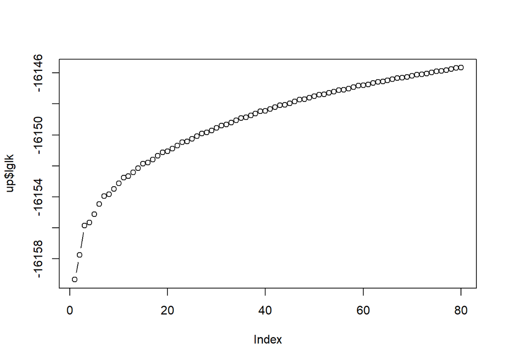

```r
plot(up$lglk,type = 'b')
```

The $||\hat{U} - U||^2_F$ is:

```r
sum((ttl(up$G,list(up$A,up$B,up$C),ms = c(1,2,3))@data - U)^2)
```

```
## [1] 6228.66
```

## Part 3: Real data

Then we apply our read data:

```r
data = readMat('dnations.mat')
data = data$R
data[is.na(data)] = 0
data[1,1,]
```

```
##  [1] 0 0 0 0 0 0 0 0 0 0 0 0 0 0 0 0 0 0 0 0 0 0 0 0 0 0 0 0 0 0 0 0 0 0 0
## [36] 0 0 0 0 0 0 0 0 0 0 0 0 0 0 0 0 0 0 0 0 0
```

```r
up = update_binary(data,c(4,4,5),5)
```

```
## [1] 1
```

```
## [1] 2
```

[output not shown]

[output cut: 34 more lines]

[output not shown]

```
## [1] 3
```

[output not shown]

```
## [1] 4
```

```
## [1] 5
```

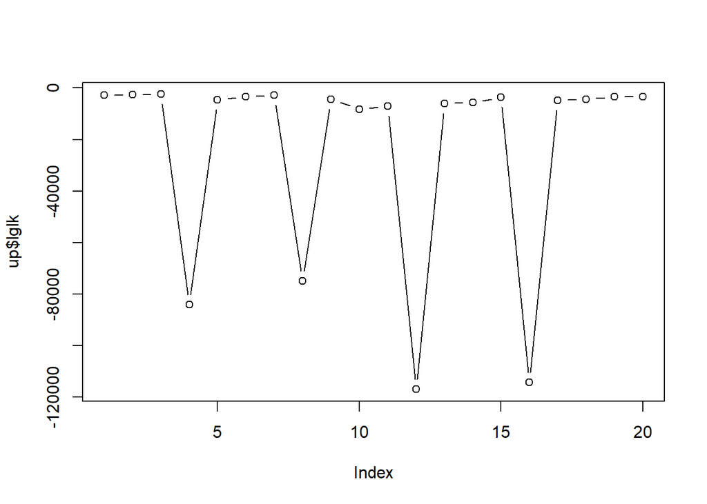

```r
plot(up$lglk,type = 'b')
```

The result is unreasonable, but it makes more sense if I set core_shape to be smaller, say (2,2,3).

```r
up = update_binary(data,c(2,2,3),5)
```

```
## [1] 1
```

```
## [1] 2
```

```
## [1] 3
```

```
## [1] 4
```

```
## [1] 5
```

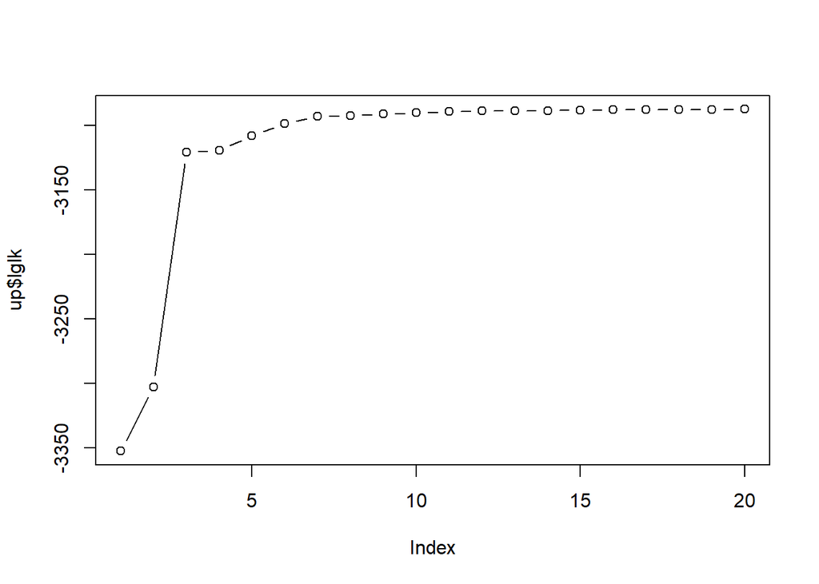

```r
plot(up$lglk,type = 'b')
```